# Self-Driving Car Engineer Nanodegree

## Project: Build a Traffic Sign Recognition Classifier

## Step 0: Load The Data

Load the German Traffic Signs Dataset

```python
# import common libs
import matplotlib.pyplot as plt
import numpy as np
import cv2
```

```python
# Load pickled data
import pickle

# file paths to saved the training and testing data
training_file = './traffic-signs-data/train.p'
validation_file= './traffic-signs-data/valid.p'
testing_file = './traffic-signs-data/test.p'

with open(training_file, mode='rb') as f:
    train = pickle.load(f)
with open(validation_file, mode='rb') as f:
    valid = pickle.load(f)
with open(testing_file, mode='rb') as f:
    test = pickle.load(f)

X_train, y_train = train['features'], train['labels']
X_valid, y_valid = valid['features'], valid['labels']
X_test, y_test = test['features'], test['labels']
```

## Step 1: Dataset Summary & Exploration

The pickled data is a dictionary with 4 key/value pairs:

- `'features'` is a 4D array containing raw pixel data of the traffic sign images, (num examples, width, height, channels).
- `'labels'` is a 1D array containing the label/class id of the traffic sign. The file `signnames.csv` contains id -> name mappings for each id.
- `'sizes'` is a list containing tuples, (width, height) representing the original width and height the image.
- `'coords'` is a list containing tuples, (x1, y1, x2, y2) representing coordinates of a bounding box around the sign in the image. **THESE COORDINATES ASSUME THE ORIGINAL IMAGE. THE PICKLED DATA CONTAINS RESIZED VERSIONS (32 by 32) OF THESE IMAGES**

### Basic Summary of the Dataset

```python
# Number of training examples
n_train = X_train.shape[0]

# Number of validation examples
n_validation = X_valid.shape[0]

# Number of testing examples.
n_test = X_test.shape[0]

# The shape of an traffic sign image
image_shape = X_train[0].shape  # shape of first sample

# How many unique classes/labels there are in the dataset
n_classes = len(set(y_train))

print("Number of training examples =", n_train)
print("Number of testing examples =", n_test)
print("Image data shape =", image_shape)
print("Number of classes =", n_classes)
```

```
Number of training examples = 34799
Number of testing examples = 12630
Image data shape = (32, 32, 3)
Number of classes = 43
```

### Dataset Exploration

#### Label Names

```python
import csv
name_dict = {}
with open('./signnames.csv', newline='') as csvfile:
    reader = csv.reader(csvfile)
    next(reader)
    for row in reader:
        print(row)
        name_dict[int(row[0])]=row[1]
```

```
['0', 'Speed limit (20km/h)']
['1', 'Speed limit (30km/h)']
['2', 'Speed limit (50km/h)']
['3', 'Speed limit (60km/h)']
['4', 'Speed limit (70km/h)']
['5', 'Speed limit (80km/h)']
['6', 'End of speed limit (80km/h)']
['7', 'Speed limit (100km/h)']
['8', 'Speed limit (120km/h)']
['9', 'No passing']
['10', 'No passing for vehicles over 3.5 metric tons']
['11', 'Right-of-way at the next intersection']
['12', 'Priority road']
['13', 'Yield']
['14', 'Stop']
['15', 'No vehicles']
['16', 'Vehicles over 3.5 metric tons prohibited']
['17', 'No entry']
['18', 'General caution']
['19', 'Dangerous curve to the left']
['20', 'Dangerous curve to the right']
['21', 'Double curve']
['22', 'Bumpy road']
['23', 'Slippery road']
['24', 'Road narrows on the right']
['25', 'Road work']
['26', 'Traffic signals']
['27', 'Pedestrians']
['28', 'Children crossing']
['29', 'Bicycles crossing']
['30', 'Beware of ice/snow']
['31', 'Wild animals crossing']
['32', 'End of all speed and passing limits']
['33', 'Turn right ahead']
['34', 'Turn left ahead']
['35', 'Ahead only']
['36', 'Go straight or right']
['37', 'Go straight or left']
['38', 'Keep right']
['39', 'Keep left']
['40', 'Roundabout mandatory']
['41', 'End of no passing']
['42', 'End of no passing by vehicles over 3.5 metric tons']
```

#### Class Distrubution

Plot class label histogram - dataset is biased due to some classes having few samples.

> We'll need to generate some fake deformed additional data to balance the classes later on.

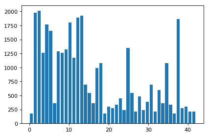

```python
plt.figure(dpi=80)
plt.hist(y_train, n_classes,align='mid', rwidth=0.8)
plt.show()
```

> We can see the images are grouped and ordered - we'll need to shuffle the data

```python
print(y_train[0:300])
```

```
[41 41 41 41 41 41 41 41 41 41 41 41 41 41 41 41 41 41 41 41 41 41 41 41
 41 41 41 41 41 41 41 41 41 41 41 41 41 41 41 41 41 41 41 41 41 41 41 41
 41 41 41 41 41 41 41 41 41 41 41 41 41 41 41 41 41 41 41 41 41 41 41 41
 41 41 41 41 41 41 41 41 41 41 41 41 41 41 41 41 41 41 41 41 41 41 41 41
 41 41 41 41 41 41 41 41 41 41 41 41 41 41 41 41 41 41 41 41 41 41 41 41
 41 41 41 41 41 41 41 41 41 41 41 41 41 41 41 41 41 41 41 41 41 41 41 41
 41 41 41 41 41 41 41 41 41 41 41 41 41 41 41 41 41 41 41 41 41 41 41 41
 41 41 41 41 41 41 41 41 41 41 41 41 41 41 41 41 41 41 41 41 41 41 41 41
 41 41 41 41 41 41 41 41 41 41 41 41 41 41 41 41 41 41 31 31 31 31 31 31
 31 31 31 31 31 31 31 31 31 31 31 31 31 31 31 31 31 31 31 31 31 31 31 31
 31 31 31 31 31 31 31 31 31 31 31 31 31 31 31 31 31 31 31 31 31 31 31 31
 31 31 31 31 31 31 31 31 31 31 31 31 31 31 31 31 31 31 31 31 31 31 31 31
 31 31 31 31 31 31 31 31 31 31 31 31]
```

#### Image Exploration

> Some images are very dark - we'll need to normalize later to avoid intensity bias

[figure not shown]

```python
NUM_ROWS = 5
NUM_COLS = 9

smpl = {y_train[i]:i for i in range(len(y_train))}

fig, ax = plt.subplots(NUM_ROWS,NUM_COLS, dpi=160)
ax = ax.ravel()

for i in range(NUM_ROWS*NUM_COLS):
    if i < n_classes:
        ax[i].axis('off')
        ax[i].imshow(X_train[smpl[i]])
    else:
        fig.delaxes(ax[i])

fig.tight_layout()
fig.subplots_adjust(hspace=0, wspace=0)
```

### Priors

#### Dataset Origin

First, I've investigated the origins of the dataset - http://benchmark.ini.rub.de/?section=gtsrb&subsection=dataset. It looks like it was originally much more extensive, I'm guessing it was pre-processed by Udacity to fit students needs better.

#### Non-local Information

There's an international convention for traffic signs and rules: https://en.wikipedia.org/wiki/Vienna_Convention_on_Road_Signs_and_Signals#Road_signs

There's a lot of data there which can't be learned from the dataset: categories, borders, shapes, colors, etc. One particulary important conclusion: signs differ between countries and regions in geometry and color. Consequentially, our classifier will be overfitted to the German convention. Furthermore, there are signs which differ ONLY in one dimension such as chroma, intensity, geometry and sometimes even interpertation (e.g MPH vs KPH speed limit). Therefore, while various dimensionality reduction and downsampling may vastly improve performance and accuracy (even in the test), for some theoretical real world usage it might be unwise to discard these data.

[figure not shown]

## Step 2: Preprocessing

1. Cleaning
2. Imputation
3. Normalization
4. Dimensionality Reduction
5. Randomization

### Cleaning

The dataset seems to be very clean. I've tried to check for various faults to no avail - although didn't spend much time on it, so the check was very shallow.

### Imputation

We've seen the classes have an unbalanced sample quantity. We'll generate some by slightly deforming existing samples. The deformations are: blurring, rotation, scaling, shear, perpective.

```python
# calculate the sample ranges
rngs = {i:np.argwhere(y_train==i).flatten() for i in range(n_classes)}
counts = {i: len(rngs[i]) for i in range(n_classes)}
max_count = max([counts[i] for i in range(n_classes)])


tot_count = sum([max_count-counts[i] for i in range(n_classes)])
deformed=np.empty((tot_count,32,32,3), dtype=np.uint8)
deformed_labels = np.empty(tot_count, dtype=np.uint8)

# rotate and scale down matrices
rot_cw = cv2.getRotationMatrix2D((16,16),10,0.9)
rot_ccw = cv2.getRotationMatrix2D((16,16),-10,0.9)
# perpesctive transform matrix
wrp_prsp = np.asarray([[ 0.9,  0.2, -2.0],[ 0.2, 1.0,  -1.0]])

last = 0
for i in range(n_classes):
    rnd = np.random.choice(rngs[i],size=max_count-counts[i])
    for r in rnd:
        if last%5 == 0:
            # avg blur
            deformed[last] = cv2.blur(X_train[r],(3,3))
        elif last%5 == 1:
            # median blur
            deformed[last] = cv2.medianBlur(X_train[r],3)
        elif last%5 == 2:
            # rotate clockwise degrees
            deformed[last] = cv2.warpAffine(X_train[r],rot_cw,(32,32))
        elif last%5 == 3:
            # rotate counter-clockwise degrees
            deformed[last] = cv2.warpAffine(X_train[r],rot_ccw,(32,32))
        elif last%5 == 4:
            deformed[last] = cv2.warpAffine(X_train[r],wrp_prsp,(32,32))
        deformed_labels[last] = i
        last+=1

X_train = np.append(X_train,deformed,axis=0)
y_train = np.append(y_train,deformed_labels)
n_train = y_train.shape[0]
```

#### Example

[figure not shown]

```python
img = X_train[5000]
wrpd0 = cv2.blur(img,(3,3))
wrpd1 = cv2.medianBlur(img,3)
wrpd2 = cv2.warpAffine(img,rot_cw,(32,32))
wrpd3 = cv2.warpAffine(img,rot_ccw, (32,32))
wrpd4 = cv2.warpAffine(img, wrp_prsp, (32,32))

out = np.concatenate((img,wrpd0,wrpd1,wrpd2, wrpd3, wrpd4), axis=1)
plt.imshow(out)
plt.show()
```

### Normalization

Global normalization is implemented as simplified whitening of each color channel: $ x = {x - \hat{x} \over \sigma(x) }$ for every pixel x, across all samples

```python
avg = np.mean(X_train,axis=0)
stddv = np.std(X_train,axis=0)
X_train = (X_train-avg)/stddv
X_valid = (X_valid-avg)/stddv
X_test = (X_test-avg)/stddv
print(X_train[0,:,:,0])
```

```
[[-0.5364916  -0.55258156 -0.55499755 ..., -0.34754479 -0.35842024
  -0.35555365]
 [-0.52214988 -0.55087146 -0.55356882 ..., -0.34508283 -0.35613631
  -0.36664526]
 [-0.53190166 -0.54821163 -0.5633516  ..., -0.34085675 -0.35139997
  -0.36217158]
 ...,
 [-0.30587994 -0.2921308  -0.26514525 ..., -0.44235888 -0.41974687
  -0.36040357]
 [-0.28799707 -0.27371925 -0.24537551 ..., -0.43938098 -0.41550706
  -0.3991376 ]
 [-0.26894227 -0.25476065 -0.22560525 ..., -0.43752759 -0.42831651
  -0.43899182]]
```

```python
# save so we won't have to recalculate
status = cv2.imwrite('./avg.jpg',avg[:,:,0])
print(status)
status = cv2.imwrite('./stddv.jpg',stddv[:,:,0])
print(status)
```

```
True
True
```

#### Example

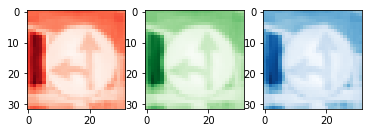

```python
fig, ax = plt.subplots(1,3)
img = X_train[5000]
ax[0].imshow(img[:,:,0], cmap='Reds')
ax[1].imshow(img[:,:,1], cmap='Greens')
ax[2].imshow(img[:,:,2], cmap='Blues')
plt.show()
```

Local normalization - not sure it's needed, unused for now

```python
#         img = X_train[smpl[i]][:,:,0].astype(np.float32)/255.0
#         avgfilt = cv2.blur(img,(5,5))
#         sqrfilt = cv2.blur(img**2,(5,5))
#         stdfilt = cv2.pow(sqrfilt-avgfilt**2,0.5)
#         img = img-avgfilt
#         img = np.where(stdfilt>1,img/stdfilt,img)
```

### Dimensionality Reduction

#### Principal Component Analysis

```python
img = np.reshape(X_train.T,(3,-1))  # np.cov requires a 2d array
# calc eigenvalues and vectors via covariance matrix
eigval, eigvec = np.linalg.eig(np.cov(img))

print(eigval)
print(eigvec)
```

```
[ 2.84689607  0.13824068  0.01486329]
[[-0.56875122 -0.74803477  0.34200297]
 [-0.58955111  0.08080827 -0.80367874]
 [-0.57354297  0.6587215   0.48696453]]
```

#### Discarding Color Channels

```python
# drop the green,blue channels and reshape to fit NN expected shape
X_train = np.reshape(X_train[:,:,:,0],(-1,32,32,1))
X_valid = np.reshape(X_valid[:,:,:,0],(-1,32,32,1))
X_test = np.reshape(X_test[:,:,:,0],(-1,32,32,1))
```

Result:

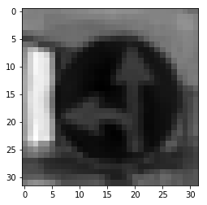

```python
plt.imshow(X_train[5000,:,:,0], cmap='gray')
plt.show()
```

### Randomization

Shuffle the training dataset

```python
from sklearn.utils import shuffle

X_train, y_train = shuffle(X_train, y_train)
```

Demonstrate randomized order:

```python
print( [y_train[i] for i in range(100)])
```

[output not shown]

## Step 3: Model Architecture

#### Overview

It's basically LeNet with modifications:

- It looked like some features were smaller than 5x5, so first layer filters are now 3x3.
- It looked liked the downsampling was happening too fast, so I've added a convolutional layer and more filters.
- After expanding the convolutional layers, it now appeared like the fully connected layers were too small and few. Hence, I've added an extra layer.
- The expanded network seemed much more complex, and therefore prone to overfit. I've added dropout layers to both types of layers, with a different probability for each type.
- Learning rate and batch size were reduced after noticing the training converges much more smoothly and consistently with these values values.
- Epochs set to 64 as that's about the amount of time it takes the network to converge

The above steps culminated in an ~4% validation accuracy over LeNet with same data and preprocessing.

#### Layers

*input*: 32x32x1

1. Convolutional -> ReLU -> dropout -> (32,32,8)
2. Convolutional -> ReLU -> max pool -> dropout -> (14,14,16)
3. Convolutional -> ReLU -> max pool -> dropout -> (6,6,32) -> flatten -> (1152)
4. Fully connected -> ReLU -> dropout -> (512)
5. Fully connected -> ReLU -> dropout -> (256)
6. Fully connected -> ReLU -> dropout -> (128)
7. Fully connected -> *output* -> (43)

```python
import tensorflow as tf
from tensorflow.contrib.layers import flatten
```

```python
EPOCHS = 64
BATCH_SIZE = 64
```

```python
def RoNet(x):
    # Arguments used for tf.truncated_normal, randomly defines variables for the weights and biases for each layer
    mu = 0
    sigma = 0.1

    # Layer 0: Convolutional
    conv0_W = tf.Variable(tf.truncated_normal(shape=(3, 3, 1, 8), mean = mu, stddev = sigma))
    conv0_b = tf.Variable(tf.zeros(8))
    conv0   = tf.nn.conv2d(x, conv0_W, strides=[1, 1, 1, 1], padding='SAME') + conv0_b
    conv0 = tf.nn.relu(conv0)
    conv0 = tf.nn.dropout(conv0, keep_p_conv)

    # Layer 1: Convolutional
    conv1_W = tf.Variable(tf.truncated_normal(shape=(3, 3, 8, 16), mean = mu, stddev = sigma))
    conv1_b = tf.Variable(tf.zeros(16))
    conv1   = tf.nn.conv2d(conv0, conv1_W, strides=[1, 1, 1, 1], padding='VALID') + conv1_b
    conv1 = tf.nn.relu(conv1)
    conv1 = tf.nn.max_pool(conv1, ksize=[1, 3, 3, 1], strides=[1, 2, 2, 1], padding='VALID')
    conv1 = tf.nn.dropout(conv1, keep_p_conv)

    # Layer 2: Convolutional
    conv2_W = tf.Variable(tf.truncated_normal(shape=(3, 3, 16, 32), mean = mu, stddev = sigma))
    conv2_b = tf.Variable(tf.zeros(32))
    conv2   = tf.nn.conv2d(conv1, conv2_W, strides=[1, 1, 1, 1], padding='VALID') + conv2_b
    conv2 = tf.nn.relu(conv2)
    conv2 = tf.nn.max_pool(conv2, ksize=[1, 2, 2, 1], strides=[1, 2, 2, 1], padding='VALID')
    conv2 = tf.nn.dropout(conv2, keep_p_conv)

    # Layer 3: Fully Connected
    flat  = flatten(conv2)
    fc1_W  = tf.Variable(tf.truncated_normal(shape=(1152, 512), mean = mu, stddev = sigma))
    fc1_b  = tf.Variable(tf.zeros(512))
    fc1    = tf.matmul(flat, fc1_W) + fc1_b
    fc1    = tf.nn.relu(fc1)
    fc1    = tf.nn.dropout(fc1, keep_p_fc)

    # Later 4: Fully Connected
    fc2_W  = tf.Variable(tf.truncated_normal(shape=(512, 256), mean = mu, stddev = sigma))
    fc2_b  = tf.Variable(tf.zeros(256))
    fc2    = tf.matmul(fc1, fc2_W) + fc2_b
    fc2    = tf.nn.relu(fc2)
    fc2    = tf.nn.dropout(fc2, keep_p_fc)

    # Layer 5: Fully Connected
    fc3_W  = tf.Variable(tf.truncated_normal(shape=(256, 128), mean = mu, stddev = sigma))
    fc3_b  = tf.Variable(tf.zeros(128))
    fc3 = tf.matmul(fc2, fc3_W) + fc3_b
    fc3    = tf.nn.relu(fc3)
    fc3    = tf.nn.dropout(fc3, keep_p_fc)

    # Layer 6: Fully Connected - output
    fc4_W  = tf.Variable(tf.truncated_normal(shape=(128, 43), mean = mu, stddev = sigma))
    fc4_b  = tf.Variable(tf.zeros(43))
    logits = tf.matmul(fc3, fc4_W) + fc4_b

    return logits
```

```python
x = tf.placeholder(tf.float32, (None, 32, 32, 1))
y = tf.placeholder(tf.int32, (None))
keep_p_conv = tf.placeholder(tf.float32)
keep_p_fc = tf.placeholder(tf.float32)
one_hot_y = tf.one_hot(y, 43)
```

```python
rate = 0.0001

logits = RoNet(x)
cross_entropy = tf.nn.softmax_cross_entropy_with_logits(labels=one_hot_y, logits=logits)
loss_operation = tf.reduce_mean(cross_entropy)
optimizer = tf.train.AdamOptimizer(learning_rate = rate)
training_operation = optimizer.minimize(loss_operation)
```

```python
correct_prediction = tf.equal(tf.argmax(logits, 1), tf.argmax(one_hot_y, 1))
accuracy_operation = tf.reduce_mean(tf.cast(correct_prediction, tf.float32))
saver = tf.train.Saver()

def evaluate(X_data, y_data):
    num_examples = len(X_data)
    total_accuracy = 0
    sess = tf.get_default_session()
    for offset in range(0, num_examples, BATCH_SIZE):
        batch_x, batch_y = X_data[offset:offset+BATCH_SIZE], y_data[offset:offset+BATCH_SIZE]
        accuracy = sess.run(accuracy_operation, feed_dict={x: batch_x, y: batch_y, keep_p_conv:1.0, keep_p_fc:1.0})
        total_accuracy += (accuracy * len(batch_x))
    return total_accuracy / num_examples
```

```python
with tf.Session() as sess:
    sess.run(tf.global_variables_initializer())
    num_examples = len(X_train)

    print("Training...")
    print()
    for i in range(EPOCHS):
        X_train, y_train = shuffle(X_train, y_train)
        for offset in range(0, num_examples, BATCH_SIZE):
            end = offset + BATCH_SIZE
            batch_x, batch_y = X_train[offset:end], y_train[offset:end]
            sess.run(training_operation, feed_dict={x: batch_x, y: batch_y, keep_p_conv:0.80, keep_p_fc:0.60})

        validation_accuracy = evaluate(X_valid, y_valid)
        print("EPOCH {} ...".format(i+1))
        print("Validation Accuracy = {:.3f}".format(validation_accuracy))
        print()


    saver.save(sess, './ronet')
    print("Model saved")
```

```
Training...

EPOCH 1 ...
Validation Accuracy = 0.108

EPOCH 2 ...
Validation Accuracy = 0.425

EPOCH 3 ...
Validation Accuracy = 0.620

EPOCH 4 ...
Validation Accuracy = 0.704

EPOCH 5 ...
Validation Accuracy = 0.780

EPOCH 6 ...
Validation Accuracy = 0.813

EPOCH 7 ...
Validation Accuracy = 0.851

EPOCH 8 ...
Validation Accuracy = 0.870

EPOCH 9 ...
Validation Accuracy = 0.887

EPOCH 10 ...
Validation Accuracy = 0.899

EPOCH 11 ...
Validation Accuracy = 0.913

EPOCH 12 ...
Validation Accuracy = 0.912

EPOCH 13 ...
Validation Accuracy = 0.924
```

[output cut: 140 more lines]

```
Validation Accuracy = 0.972

EPOCH 61 ...
Validation Accuracy = 0.971

EPOCH 62 ...
Validation Accuracy = 0.971

EPOCH 63 ...
Validation Accuracy = 0.970

EPOCH 64 ...
Validation Accuracy = 0.974

Model saved
```

### Train, Validate and Test the Model

```python
with tf.Session() as sess:
    saver.restore(sess, tf.train.latest_checkpoint('.'))

    train_accuracy = evaluate(X_train, y_train)
    print("Train Accuracy = {:.3f}".format(train_accuracy))

    valid_accuracy = evaluate(X_valid, y_valid)
    print("Valid Accuracy = {:.3f}".format(valid_accuracy))

    test_accuracy = evaluate(X_test, y_test)
    print("Test Accuracy = {:.3f}".format(test_accuracy))
```

```
Train Accuracy = 0.998
Valid Accuracy = 0.974
Test Accuracy = 0.957
```

## Step 3: Test a Model on New Images

### Load and Output the Images

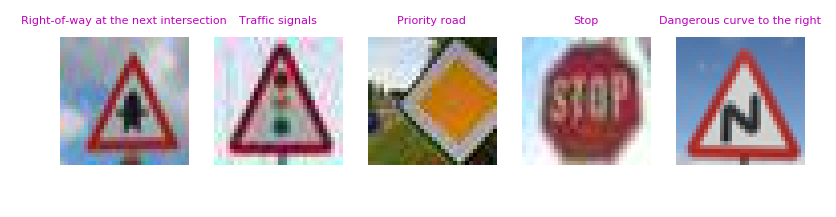

```python
%matplotlib inline
lbls = np.array([11,26,12,14,20])
ims = np.zeros((5,32,32,3), dtype=np.uint8)

fig, ax = plt.subplots(1,5, dpi=160)
for i in range(5):
    ims[i] = cv2.cvtColor(cv2.imread('./traffic-signs-extra/'+str(i)+'.jpg', cv2.IMREAD_COLOR),cv2.COLOR_BGR2RGB)
    ax[i].axis('off')
    ax[i].set_title(name_dict[lbls[i]], color='m', fontsize=5)
    ax[i].imshow(ims[i])
plt.show()
```

#### Prepress

```python
# preprocess: drop green and blue channels, normalize with training set mean and standard deviation
ims = (ims[:,:,:,0]-avg[:,:,0])/stddv[:,:,0]
ims = np.reshape(ims,(-1,32,32,1))
print(ims.shape)
```

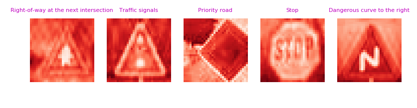

```python
fig, ax = plt.subplots(1,5, dpi=160)
for i in range(5):
    ax[i].axis('off')
    ax[i].set_title(name_dict[lbls[i]], color='m', fontsize=5)
    ax[i].imshow(ims[i,:,:,0], cmap='Reds')
plt.show()
```

### Predict the Sign Type for Each Image

```python
### Run the predictions here and use the model to output the prediction for each image.
### Make sure to pre-process the images with the same pre-processing pipeline used earlier.
### Feel free to use as many code cells as needed.

with tf.Session() as sess:
        sess.run(tf.global_variables_initializer())
        saver.restore(sess, './ronet')
        extra_accuracy = evaluate(ims, lbls)
        print("Extra Accuracy = {:.3f}".format(extra_accuracy))
```

```
Extra Accuracy = 0.600
```

### Analyze Performance

```python
### Calculate the accuracy for these 5 new images.
### For example, if the model predicted 1 out of 5 signs correctly, it's 20% accurate on these new images.

for i in range(5):
    with tf.Session() as sess:
        sess.run(tf.global_variables_initializer())
        saver.restore(sess, "./ronet")
        my_accuracy = evaluate([ims[i]], [lbls[i]])
        print('Image {}'.format(i))
        print("Image Accuracy = {:.3f}".format(my_accuracy))
        print()
```

```
Image 0
Image Accuracy = 1.000

Image 1
Image Accuracy = 1.000

Image 2
Image Accuracy = 1.000

Image 3
Image Accuracy = 0.000

Image 4
Image Accuracy = 0.000
```

### Output Top 5 Softmax Probabilities For Each Image Found on the Web

```python
# Calculate top five softmax probabilities for the predictions
with tf.Session() as sess:
    sess.run(tf.global_variables_initializer())
    saver.restore(sess, "./ronet")
    top_k = sess.run(tf.nn.top_k(tf.nn.softmax(logits), k=5), feed_dict={x: ims, y: lbls, keep_p_conv:1.0, keep_p_fc:1.0})
```

```python
# Print out top five softmax probabilities for the predictions
for j in range(5):
    print('GROUND TRUTH: ', name_dict[lbls[j]])
    for i in range(5):
        print(str(i+1)+'. ', name_dict[top_k[1][j][i]])
        print('   ', top_k[0][j][i])
    print()
```

```
GROUND TRUTH:  Right-of-way at the next intersection
1.  Right-of-way at the next intersection
    1.0
2.  Beware of ice/snow
    3.41095e-08
3.  Pedestrians
    3.18046e-10
4.  Road work
    2.31738e-11
5.  Children crossing
    7.6428e-12

GROUND TRUTH:  Traffic signals
1.  Traffic signals
    0.996741
2.  General caution
    0.00172232
3.  Right-of-way at the next intersection
    0.00094807
4.  Beware of ice/snow
    0.000562289
5.  Road work
    2.25787e-05

GROUND TRUTH:  Priority road
1.  Priority road
    0.997185
2.  Yield
    0.00254995
3.  No vehicles
    0.000169614
4.  No passing
    3.43746e-05
5.  Speed limit (60km/h)
    1.88259e-05

GROUND TRUTH:  Stop
1.  Speed limit (100km/h)
    0.560961
2.  Speed limit (120km/h)
    0.167752
3.  Speed limit (70km/h)
    0.101877
4.  Speed limit (30km/h)
    0.0941417
5.  Speed limit (80km/h)
    0.042617

GROUND TRUTH:  Dangerous curve to the right
1.  Children crossing
    0.766275
2.  Ahead only
    0.233388
3.  Speed limit (60km/h)
    0.000101051
4.  Right-of-way at the next intersection
    6.49906e-05
5.  Turn left ahead
    6.29549e-05
```